# Deep Learning with R Part 4-2

### Walkthrough – Building an Auto-Encoder

#### Get Data

Just as the previous walkthru, we will again use the smartphone activity data used before. This time we search for outliers using H<sub>2</sub>O.

```r
try(rm(list=ls()), silent = TRUE)
try(lapply(paste('package:',names(sessionInfo()$otherPkgs),sep=""), detach,character.only=TRUE,unload=TRUE), silent = TRUE)
#Apply packages
if(!require(easypackages)){
    install.packages("easypackages")
    library(easypackages)
}
packages("caret", "h2o", prompt = FALSE)
```

```r
use.train.x <- read.table("../Essentials/data/X_train.txt")
use.train.y <- read.table("../Essentials/data/y_train.txt")[[1]]
use.test.x <- read.table("../Essentials/data/X_test.txt")
use.test.y <- read.table("../Essentials/data/y_test.txt")[[1]]
use.labels <- read.table("../Essentials/data/activity_labels.txt")

localH2O = h2o.init(max_mem_size = "3G", nthreads = 2)
h2oactivity.train <- as.h2o(use.train.x, destination_frame = "h2oactivitytrain")
h2oactivity.test <- as.h2o(use.test.x, destination_frame = "h2oactivitytest")

save(use.test.x, use.test.y, use.train.x, use.train.y, h2oactivity.train, h2oactivity.test, use.labels, file="../Essentials/getDataWalkthru2.RData")
```

```
##
## H2O is not running yet, starting it now...
##
## Note:  In case of errors look at the following log files:
##     C:\Users\czwea\AppData\Local\Temp\Rtmpm8XH5r/h2o_czwea_started_from_r.out
##     C:\Users\czwea\AppData\Local\Temp\Rtmpm8XH5r/h2o_czwea_started_from_r.err
##
##
## Starting H2O JVM and connecting:  Connection successful!
##
## R is connected to the H2O cluster:
##     H2O cluster uptime:         2 seconds 984 milliseconds
##     H2O cluster version:        3.10.4.6
##     H2O cluster version age:    2 months and 27 days
##     H2O cluster name:           H2O_started_from_R_czwea_pbd473
##     H2O cluster total nodes:    1
##     H2O cluster total memory:   2.67 GB
##     H2O cluster total cores:    4
##     H2O cluster allowed cores:  2
##     H2O cluster healthy:        TRUE
##     H2O Connection ip:          localhost
##     H2O Connection port:        54321
##     H2O Connection proxy:       NA
##     H2O Internal Security:      FALSE
##     R Version:                  R version 3.4.0 (2017-04-21)
```

Use two layers with 100 hidden neurons each. No specific regularization used. Given that there are significantly fewer hidden neurons than there are input variables, the model simplicity may provide adequate regularization.

```r
mu1 <- h2o.deeplearning(x = colnames(h2oactivity.train), training_frame= h2oactivity.train,
              validation_frame = h2oactivity.test, activation = "Tanh", autoencoder = TRUE,
              hidden = c(100, 100), epochs = 30, sparsity_beta = 0, input_dropout_ratio = 0, l1 = 0, l2 = 0)

   save(mu1, file="../Essentials/mu1-2.RData")
```

```
## Model Details:
## ==============
##
## H2OAutoEncoderModel: deeplearning
## Model ID:  DeepLearning_model_R_1500911346989_1
## Status of Neuron Layers: auto-encoder, gaussian distribution, Quadratic loss, 122,961 weights/biases, 1.5 MB, 111,876 training samples, mini-batch size 1
##   layer units  type dropout       l1       l2 mean_rate rate_rms momentum
## 1     1   561 Input  0.00 %
## 2     2   100  Tanh  0.00 % 0.000000 0.000000  0.039153 0.019330 0.000000
## 3     3   100  Tanh  0.00 % 0.000000 0.000000  0.011063 0.003303 0.000000
## 4     4   561  Tanh         0.000000 0.000000  0.029749 0.013184 0.000000
##   mean_weight weight_rms mean_bias bias_rms
## 1
## 2   -0.001189   0.075201  0.012574 0.107094
## 3   -0.000533   0.063426  0.006237 0.050046
## 4    0.001740   0.055420  0.039963 0.047594
##
##
## H2OAutoEncoderMetrics: deeplearning
## ** Reported on training data. **
##
## Training Set Metrics:
## =====================
##
## MSE: (Extract with `h2o.mse`) 0.001018938
## RMSE: (Extract with `h2o.rmse`) 0.0319208
##
## H2OAutoEncoderMetrics: deeplearning
## ** Reported on validation data. **
##
## Validation Set Metrics:
## =====================
##
## MSE: (Extract with `h2o.mse`) 0.001090898
## RMSE: (Extract with `h2o.rmse`) 0.03302875
```

The model has a very low reconstruction error. suggesting the model is sufficiently complex to capture the key features of the data. There is no substantial difference in model performance between the training and validation data.

Extract how anomalous each case is and plot the distribution. Clearly there are a few cases that are more anomalous than the rest shown by much higher error rates.

```r
erroru1 <- as.data.frame(h2o.anomaly(mu1, h2oactivity.train))
save(erroru1, file="../Essentials/erroru1.RData")
```

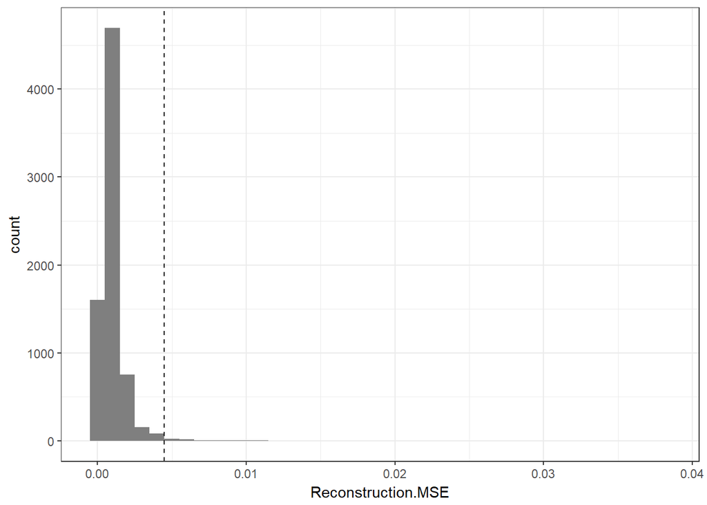

```r
load("../Essentials/erroru1.RData")
pue1 <- ggplot(erroru1, aes(Reconstruction.MSE)) +  geom_histogram(binwidth = .001, fill = "grey50") +
  geom_vline(xintercept = quantile(erroru1[[1]], probs = .99), linetype = 2) + theme_bw()
print(pue1)
```

One way to try to explore these anomalous cases further is to examine whether any of the activities tend to have more or less anomalous values. Do this by finding which cases are anomalous arbitrarily defined as the top 1% of error rates. Extract the activities of those cases and plotting them. The majority of anomalous cases come from walking downstairs or lying down. With a high error in recreating the inputs, the deep features may be a (relatively) poor representation of the input for those cases. In practice if we were classifying based on these results, we might exclude these cases as they do not seem to fit the features the model has learned.

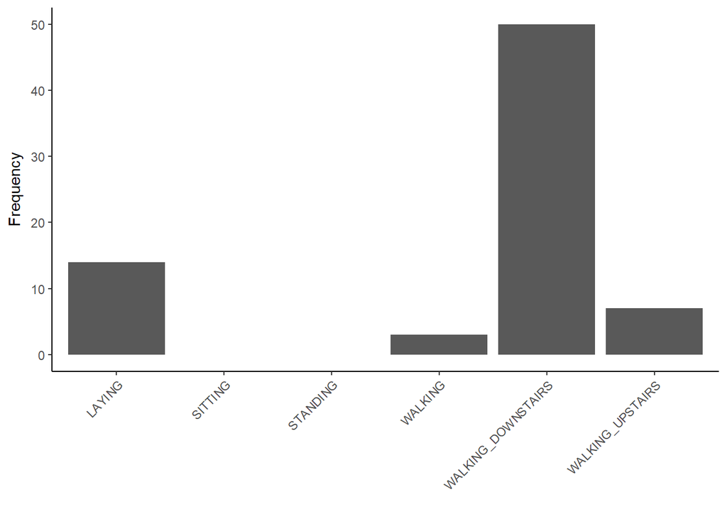

```r
i.anomolous <- erroru1$Reconstruction.MSE >= quantile(erroru1[[1]], probs = .99)

pu.anomolous <- ggplot(as.data.frame(table(use.labels$V2[use.train.y[i.anomolous]])), aes(Var1, Freq)) +
     geom_bar(stat = "identity") + xlab("") + ylab("Frequency") + theme_classic() +
     theme(axis.text.x = element_text(angle = 45, hjust = 1, vjust = 1))
print(pu.anomolous)
```

**What we learned**: Used a deep auto-encoder model to learn the features of actimetry data from smartphones. Useful for excluding unknown or unusual activities, rather than incorrectly classifying them. For example, as part of an app that classifies what activity you engaged in for how many minutes, it may be better to simply leave out a few minutes where the model is uncertain or the hidden features do not adequately reconstruct the inputs, rather than to aberrantly call an activity walking or sitting when it was actually walking downstairs. Such work can also help to identify where the model tends to have more issues.

Similarly, we could explore financial data or credit card usage patterns. Anomalous spending patterns may indicate fraud or that a credit card has been stolen. Rather than attempt to manually search through millions of credit card transactions, one could train an auto-encoder model and use it to identify anomalies for further investigation.